# Generation of instance files

2024-09-30

## Generation of subproblems/subsets

We use the R package `gMOIP` to generate subproblems. A subproblem is generated such that all nondominated points is integer and in the hypercube $[0, 10000]^p$. A configuration is defined using:

- Number of objectives ($p$).
- Number of nondominated points (card).
- Generation method which is either
  - Points generated on the upper (u) part of a sphere resulting in many unsupported points (see Fig. 1).
  - Points generated between to hyperplanes in the middle (m) of the hypercube, resulting in both supported and unsupported points near to the hull (see Fig. 2).
  - Points generated on the lower (l) part of a sphere resulting in many supported points (see Fig. 1).

That is a subproblem can be identified using filename `Lyngesen24-sp-<p>-<card>-<gen-method>_<id>.json` where `id` denote the instance id for the same configuration.

[interactive chart not shown]

For each subproblem we calculate the statistics:

- Classification of points into supported extreme (se), supported non extreme (sne), unsupported (us).
- Number of
  - points (cardinality)
  - supported, extreme and unsupported
  - min and max value for each objective $i = 1,\ldots p$.
  - width $w_i$ = $max_i-min_i$ for each objective $i = 1,\ldots p$.

### A few plots

In total there are 600 subproblems.

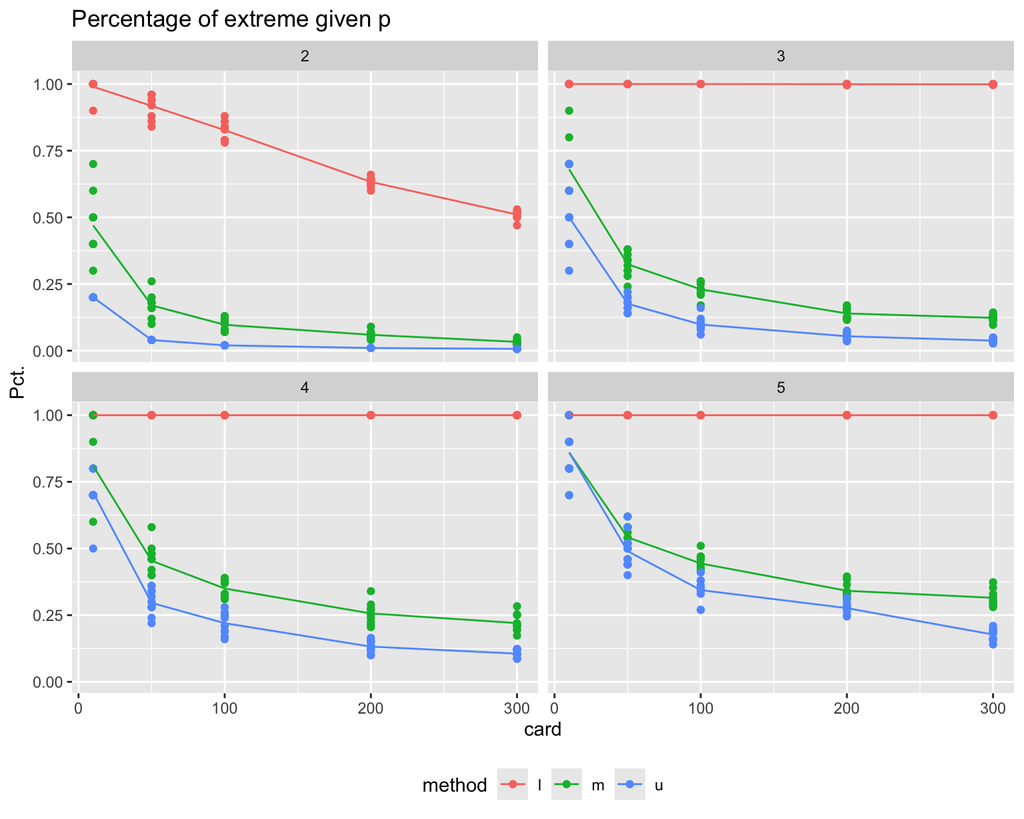

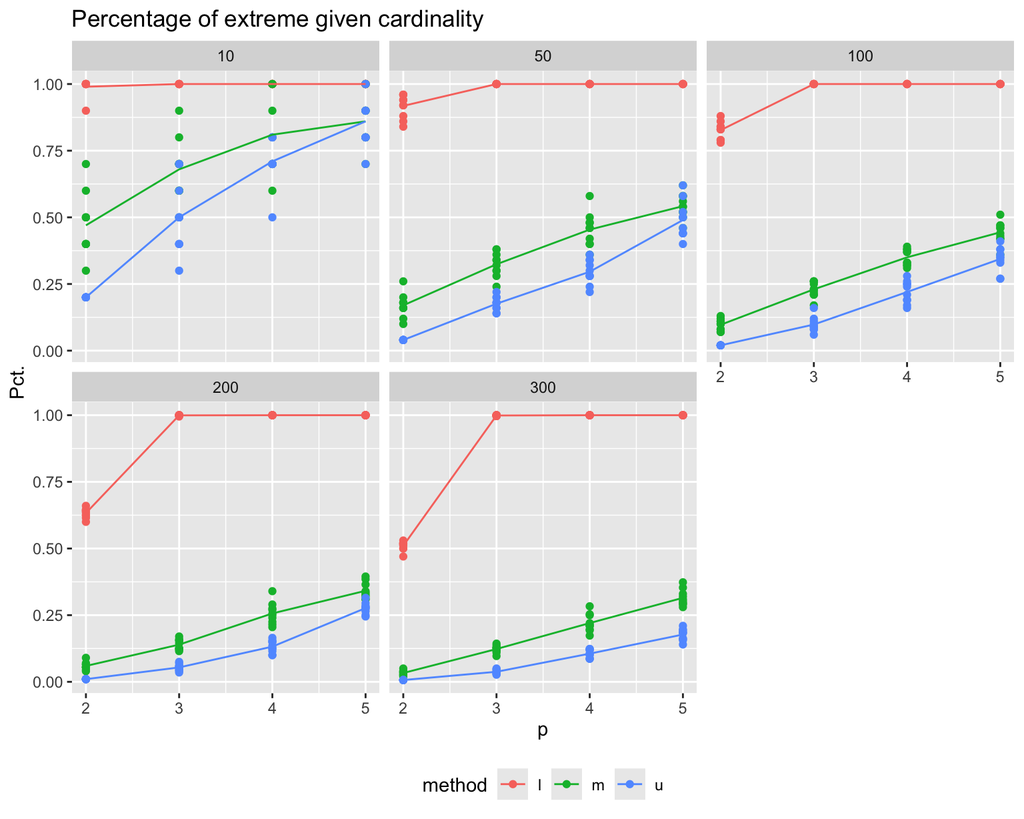

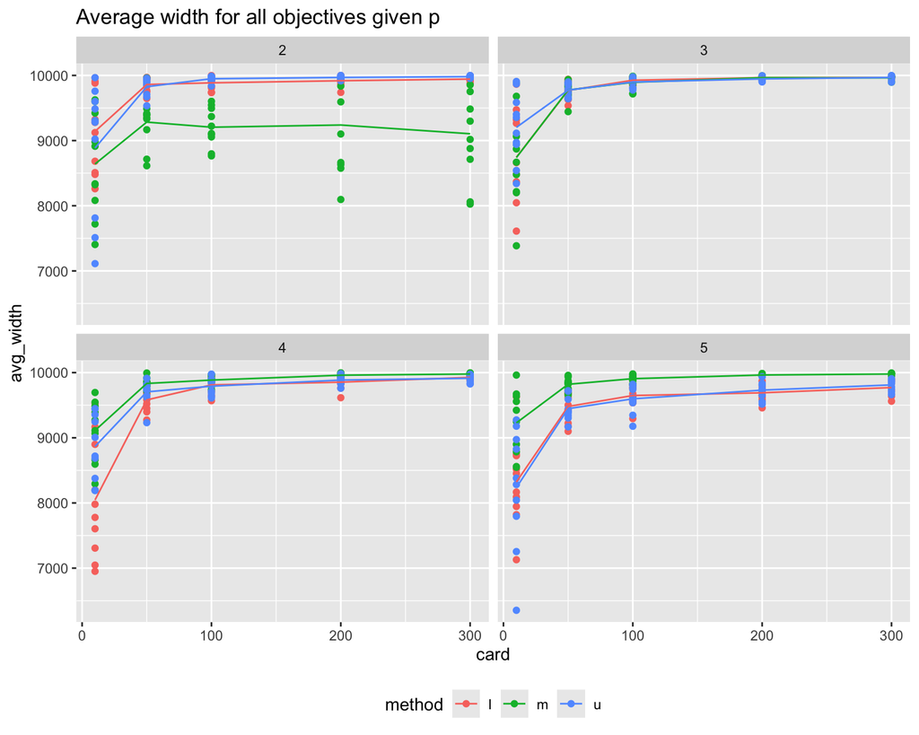

## Generation of MS problems

The problems generated consists of $2 \leq S\leq 5$ subproblems and is generated so provide a good test bed for the research questions. The naming convention is `Lyngesen24-msp-<p>-<cards>-<gen-methods>_<S>_<id>.json`

The following instance/problem groups are generated given:

- $p=2,\ldots, 5$. [4 options]
- $S=2,\ldots 5$ where $S$ is the number of subproblems. [4 options]
- All subproblems have the same method config or half have method `u` and `l`. If $S$ is odd then pick random which method should be used most. [4 options]
- Five instances for each config. [5 options]